# xwMOOC 데이터 과학

대한민국 인구변화(2000 vs 2015) - treemap

xwMOOC

2018-01-13

## 1. 대한민국의 인구순 도시 목록

대한민국의 인구순 도시를 정리한 데이터를 [위키 웹페이지](https://ko.wikipedia.org/wiki/%EB%8C%80%ED%95%9C%EB%AF%BC%EA%B5%AD%EC%9D%98_%EC%9D%B8%EA%B5%AC%EC%88%9C_%EB%8F%84%EC%8B%9C_%EB%AA%A9%EB%A1%9D)에서 가져와서 `treemap`으로 시각화하면 광역시도와 각 도에 포함된 시인구에 대한 정보를 쉽게 파악할 수 있다. 위키 웹페이지에 표현된 데이터는 5년마다 조사되는 인구주택총조사(센서스)에 근거한 것으로, 인구주택총조사 결과는 국가통계포털에서 확인할 수 있다.

## 2. 데이터 긁어와서 정제

`rvest` 팩키지에서 데이터를 가져와서 이를 `treemap`으로 처리가 가능한 형태로 가공한다.

```r
# 0. 환경설정 -----
library(rvest)
library(stringr)
library(tidyverse)
library(treemap)
library(d3treeR) # devtools::install_github("timelyportfolio/d3treeR")
library(extrafont)
loadfonts()

# 1. 데이터 가져오기 -----

Sys.setlocale("LC_ALL", "C")
```

```
[1] "C"
```

```r
url <- "https://ko.wikipedia.org/wiki/%EB%8C%80%ED%95%9C%EB%AF%BC%EA%B5%AD%EC%9D%98_%EC%9D%B8%EA%B5%AC%EC%88%9C_%EB%8F%84%EC%8B%9C_%EB%AA%A9%EB%A1%9D"

pop_dat <- read_html(url) %>%
  html_nodes(xpath = '//*[@id="mw-content-text"]/div/table') %>%
  html_table(fill = TRUE) %>%
  .[[1]]

Sys.setlocale("LC_ALL", "Korean")
```

```
[1] "LC_COLLATE=Korean_Korea.949;LC_CTYPE=Korean_Korea.949;LC_MONETARY=Korean_Korea.949;LC_NUMERIC=C;LC_TIME=Korean_Korea.949"
```

```r
# 2. 데이터 정제과정 -----

names(pop_dat) <- c("순위", "행정구역", "지역", "2015년", "2010년", "2005년", "2000년")

pop_df <- pop_dat %>%
  mutate(`2015년` = str_replace_all(`2015년`, ",", "") %>% as.integer,
         `2010년` = str_replace_all(`2010년`, ",", "") %>% as.integer,
         `2005년` = str_replace_all(`2005년`, ",", "") %>% as.integer,
         `2000년` = str_replace_all(`2000년`, ",", "") %>% as.integer) %>%
  separate(행정구역, into=c("광역시도", "시군"), sep=" ") %>%
  mutate(시군 = str_replace_all(시군, "\\[[0-9].*\\]", "")) %>%
  mutate(지역 = factor(지역))

pop_df %>%
  DT::datatable() %>%
    DT::formatCurrency(c("2015년", "2010년", "2005년", "2000년"), currency="", digits=0)
```

|  | 순위 | 광역시도 | 시군 | 지역 | 2015년 | 2010년 | 2005년 | 2000년 |
| --- | --- | --- | --- | --- | --- | --- | --- | --- |
| 1 | 1 | 서울특별시 |  | 수도권 | 9904312 | 9631482 | 9762546 | 9853972 |
| 2 | 2 | 부산광역시 |  | 경상권 | 3448737 | 3393191 | 3512547 | 3655437 |
| 3 | 3 | 인천광역시 |  | 수도권 | 2890451 | 2632035 | 2517680 | 2466338 |
| 4 | 4 | 대구광역시 |  | 경상권 | 2466052 | 2431774 | 2456016 | 2473990 |
| 5 | 5 | 대전광역시 |  | 충청권 | 1538394 | 1490158 | 1438551 | 1365961 |
| 6 | 6 | 광주광역시 |  | 전라권 | 1502881 | 1466143 | 1413644 | 1350948 |
| 7 | 7 | 경기도 | 수원시 | 수도권 | 1194313 | 1054053 | 1039233 | 944239 |
| 8 | 8 | 울산광역시 |  | 경상권 | 1166615 | 1071673 | 1044934 | 1012110 |
| 9 | 9 | 경상남도 | 창원시 | 경상권 | 1059241 | 1047488 | 1075326 | 1076448 |
| 10 | 10 | 경기도 | 고양시 | 수도권 | 990073 | 897222 | 864402 | 762598 |

[output cut: 75 more lines]

## 3. 2015년 광역시도 인구

먼저 2015년 광역시도 인구를 살펴보자.

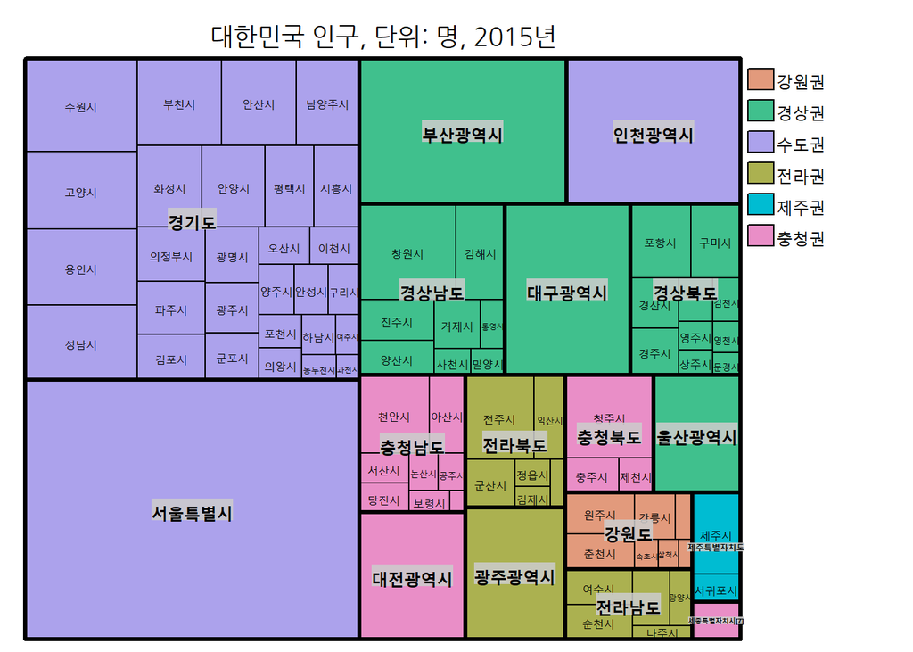

```r
# 3. 데이터 시각화 -----
## 3.1. 2015년: treemap 정적 그래프
pop_2015_treemap <- treemap(pop_df,
                       index = c("광역시도", "시군"),
                       vSize = "2015년",
                       vColor = "지역",
                       title = "대한민국 인구, 단위: 명, 2015년",
                       fontsize.labels=c(12, 8),
                       draw = TRUE,
                       type = "categorical",
                       fontfamily.title = "NanumGothic",
                       format.legend = list(scientific = FALSE, big.mark = ","),
                       title.legend="")
```

`treemap` 인터랙티브 방식으로 파고들어(drilldown)하여 2015년 각 도별로 인구를 살펴보자.

```r
## 3.2. 2015년: treemap 동적 그래프
d3tree2(pop_2015_treemap, rootname = "대한민국")
```

[interactive chart not shown]

## 4. 2000년 광역시도 인구

먼저 2000년 광역시도 인구를 살펴보자. 15년 사이 인구의 변화를 체감할 수 있다.

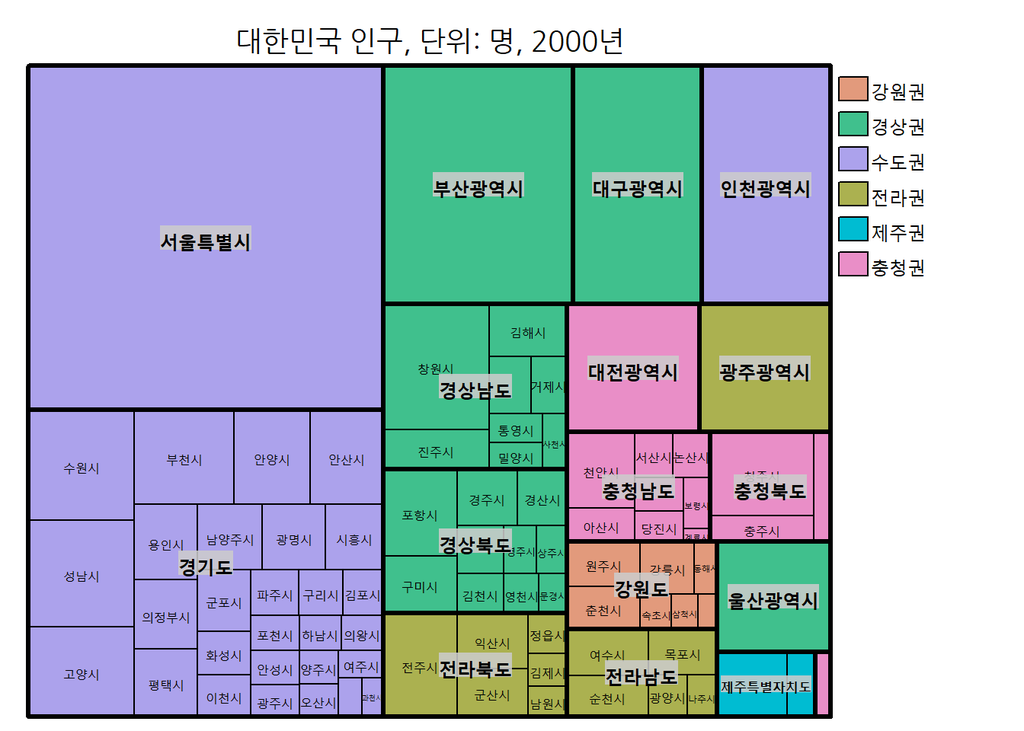

```r
## 3.3. 2000년: treemap 정적 그래프
pop_2000_treemap <- treemap(pop_df,
                            index = c("광역시도", "시군"),
                            vSize = "2000년",
                            vColor = "지역",
                            title = "대한민국 인구, 단위: 명, 2000년",
                            fontsize.labels=c(12, 8),
                            draw = TRUE,
                            type = "categorical",
                            fontfamily.title = "NanumGothic",
                            format.legend = list(scientific = FALSE, big.mark = ","),
                            title.legend="")
```

`treemap` 인터랙티브 방식으로 파고들어(drilldown)하여 2000년 각 도별로 인구를 살펴보자.

```r
## 3.4. 2000년: treemap 동적 그래프

d3tree2(pop_2000_treemap, rootname = "대한민국")
```

[interactive chart not shown]

이를 통해서 서울특별시에서 경기도로 인구가 가장 많은 지역이 바뀐 것은 기본이고 각 시도마다 인구순위 변화가 눈에 확연히 띈다.